# Análise de #LulaCovarde

Análise de #LulaCovarde Democracia e Tecnologia | ITS Rio 22 de setembro de 2022

[figure not shown]

> Destacamos que, assim como qualquer ferramenta de detecção de comportamento automatizado, o Pegabot tem limitações, especialmente, por conta das técnicas utilizadas para automação de perfis no Twitter serem atualizadas com frequência, impedindo que determinadas contas sejam identificadas pelo algoritmo. Da mesma forma, o Pegabot tem passado por um processo constante de avaliação e ajustes, para se manter atualizado frente às novas estratégias adotadas por esses perfis automatizados. Por esse motivo, procuramos não apontar esses perfis de forma direta, mas sim entender o uso de automação de forma mais ampla, identificando comportamentos que fogem do esperado ou observado, além de apontar indícios de ação coordenada por parte dos usuários ao redor de um tema ou hashtag comum.

#### Sobre os dados coletados

Coletamos 16209 tweets que mencionaram a hashtag #LulaCovarde durante o intervalo entre 20/09 (16h14) e 21/09 (12h54), totalizando aproximadamente 21 horas:

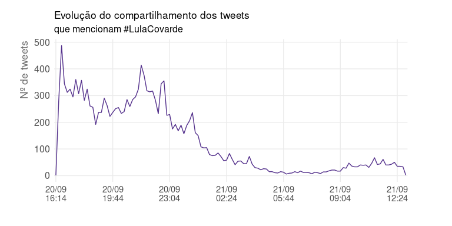

Essa hashtag mobilizou um volume relevante de compartilhamentos em um curto espaço de tempo. Verificamos que 21.6% dos registros compreendem tweets nativos, enquanto 78.4% são RTs. Além disso, identificamos que 9696 usuários compartilharam a hashtag pelo menos uma vez.

#### Sobre a frequência de tweets por usuário

O número de publicações que um usuário realiza no Twitter pode variar por uma série de motivos, como a finalidade da conta e número de seguidores, por exemplo. Por isso olhamos para a frequência de postagem por usuários para entender mais sobre o compartillhamento da hashtag. Numa primeira análise, verificamos que a distribuição da quantidade de usuários em relação ao número de tweets que eles publicam é bastante desbalanceada. 90% dos 9696 usuários contidos na base de dados coletada só fazem menção à hashtag até no máximo 2 vezes, valor de média de tweets por usuário.

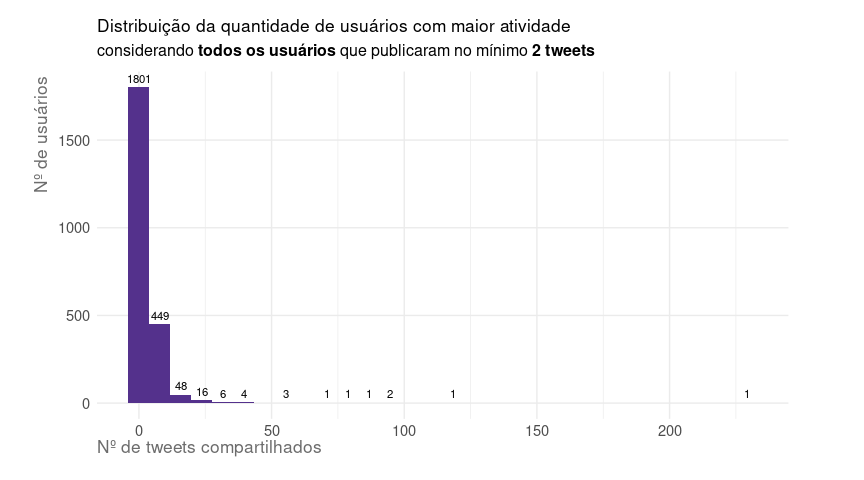

#### Os tweets que mais repercutiram

| Autor | Link | Total RTs |
| --- | --- | --- |
| @taoquei1 | https://twitter.com/taoquei1/status/1572263933347565568 | 5747 |
| @Jouberth19 | https://twitter.com/Jouberth19/status/1572282315400794113 | 1016 |
| @freu_rodrigues | https://twitter.com/freu_rodrigues/status/1572298794179645443 | 636 |
| @carloscezarcjr | https://twitter.com/carloscezarcjr/status/1572270564315627522 | 498 |
| @freu_rodrigues | https://twitter.com/freu_rodrigues/status/1572302815799689217 | 413 |
| @freu_rodrigues | https://twitter.com/freu_rodrigues/status/1572285372297527298 | 277 |
| @kaiquerson_ | https://twitter.com/kaiquerson_/status/1572306934677803010 | 231 |
| @MarioCarvalho28 | https://twitter.com/MarioCarvalho28/status/1572320190880268288 | 135 |
| @anacletogodin | https://twitter.com/anacletogodin/status/1572265146093015045 | 118 |
| @verissimomath01 | https://twitter.com/verissimomath01/status/1572285524521680904 | 105 |

#### Outros temas que apareceram

Algumas hashtags mencionadas juntamente com #LulaCovarde são relacionadas ao Lula ou Bolsonaro.

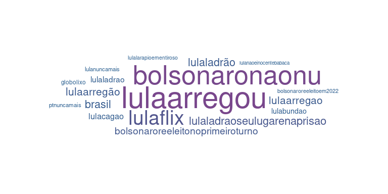